# Bayesian optimization

27/10/2023

## Link with DoE part 1

So far, considerations have been concentrated on properties of the designs of experiments first, and subsequently on modeling.

But there is a strong link with modeling, e.g., linear regression with factorial designs.

If the model is defined already, maybe the design should be selected to **directly** maximize its *quality*.

This way, depending on the choice of model, the design of experiments may be different.

We consider:

- linear regression
- Gaussian process modeling/kriging

**Sequentiality** is crucial here.

Note: lecture material adapted from [V. Picheny](https://sites.google.com/site/victorpicheny/) lectures on Design of experiments

## Optimal design for linear regression

## Linear regression

*Example:* trees data set

```r
linmod <- lm(Volume~Girth, trees); xgrid <- seq(5, 25,, 101)
preds <- predict.lm(object = linmod, newdata = data.frame(Girth = xgrid),
                    interval = "prediction")
```

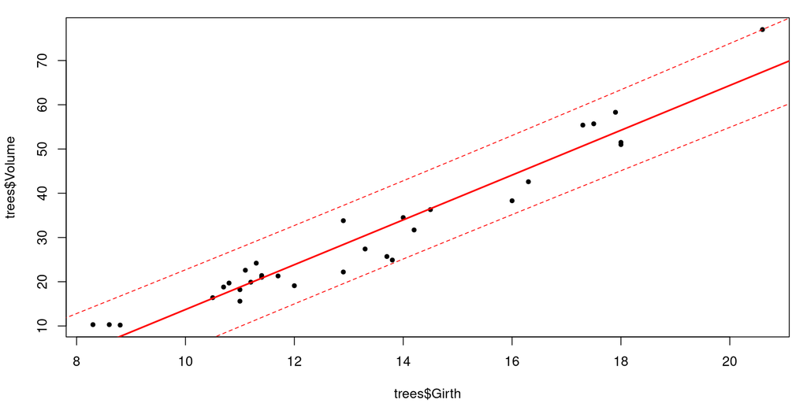

## Related optimization problem

Key quantity: \((\mathbf{F}^\top \mathbf{F})^{-1}\)

- do not depend on the \(y\)’s nor on \(\sigma^2\)

*Exercise*: 1 variable, domain = [0, 1], 1 observation, model: \(\beta_0 x\)

- choose \(x\) in order to minimize the error on \(\beta_0\)
- similarly, how to minimize the predictive variance?

## Alphabetical optimality for estimation

Key quantity: \((\mathbf{F}^\top \mathbf{F})^{-1}\)

Associated criteria related to the estimation of \(\boldsymbol{\beta}\):

**A-optimality**: minimize the sum of the variance of the coefficients, i.e., \[\min \limits_{\mathbf{X}} Trace((\mathbf{F}^\top \mathbf{F})^{-1})\]

**D-optimality**: minimize the volume of the ellipsoid defined by \((\mathbf{F}^\top \mathbf{F})^{-1}\), i.e., \[\min \limits_{\mathbf{X}} Det((\mathbf{F}^\top \mathbf{F})^{-1}) = \max \limits_{\mathbf{X}} Det((\mathbf{F}^\top \mathbf{F}))\]

**E-optimality**: minimize the maximum eigen-value of \((\mathbf{F}^\top \mathbf{F})^{-1}\), i.e., \[\min \limits_{\mathbf{X}} \max \limits_i \lambda_i\] with \(\lambda_i\) the \(i^{th}\) eigen value of \((\mathbf{F}^\top \mathbf{F})\)

## Graphical interpretation of the criteria

[figure not shown]

## Alphabetical optimality for prediction

**G-optimality**: minimize the maximum variance of the prediction on a domain \(D \in \mathbb{R}^d\), i.e., \[\min \limits_{\mathbf{X}} \max \limits_{\mathbb{x} \in D} \mathbf{f}(\mathbf{x})(\mathbf{F}^\top \mathbf{F})^{-1}\mathbf{f}(\mathbf{x})^\top\]

**I-optimality**: minimize the integral of the variance of the prediction on \(D\), i.e., \[\min \limits_{\mathbf{X}} \int \limits_{\mathbb{x} \in D} \mathbf{f}(\mathbf{x})(\mathbf{F}^\top \mathbf{F})^{-1}\mathbf{f}(\mathbf{x})^\top d\mathbf{x}\] Again, the associated optimization problems are involved, using exchange algorithms is computationally cheaper.

## Toward continuous optimal designs

*Replication* is beneficial to estimate the noise variance, even more so when this noise variance changes throughout the input domain (a.k.a., heteroskedasticity).

Suppose that some experiments have been replicated. Denote \(\bar{\mathbf{x}}_i\) the \(1 \leq i \leq n\) unique designs, \(a_i \in \mathbb{N}^*\) the corresponding number of experiments outputs \(y_i^{(j)}\) with \(j \in [1, a_i]\), \(\sum \limits_{i=1}^n a_i = N\).

In fact, for the regression model, having two observations \(y_i^{(1)}\) and \(y_i^{(1)}\), observed with normal error variance \(v(\mathbf{x}_i)\), is equivalent to observe \(\bar{y}_i = \frac{1}{2}(y_i^{(1)} + y_i^{(2)})\) with variance \(v(\mathbf{x}_i)/2\). But:

- \(n\) is potentially much smaller than \(N\), implying faster inference
- optimization problems are potentially easier (reduced dimension).

## A generalized linear regression model

Denote \(\boldsymbol{\Gamma} = \sigma^2 Diag(a_1^{-1}, \dots, a_n^{-1})\).

Generalized least-square predictor: \(\hat{\boldsymbol{\beta}} = (\mathbf{F}^\top \boldsymbol{\Gamma}\mathbf{F})^{-1}\mathbf{F} \hat{\mathbf{y}}\) where \(\hat{\mathbf{y}} = (\hat{y}_1, \dots, \hat{y}_n)^\top\)

Removing integer constraints on the \(a_i\)’s gives normalized continuous designs defined by the \(\mathbf{x}_i\)’s and corresponding weights \(\omega_i = a_i/N\), \(\sum_{i = 1}^n \omega_i= 1\).

Then:

- designs of experiments with different numbers of points can be compared
- designs of experiments can be defined by a discrete measure of probability denoted \(\xi\)
- \(M(\xi) = (\mathbf{F}^\top \boldsymbol{\Gamma}\mathbf{F}) = \int \limits_{\mathbf{x} \in D} \mathbf{f}(\mathbf{x})^\top \mathbf{f}(\mathbf{x}) d\xi(\mathbf{x})\)

## Kiefer et Wolfowitz equivalence theorem (1960)

The conditions:

- a design is D-optimal
- a design is G-optimal
- \(\max \limits_{\mathbb{x} \in D} \mathbf{f}(\mathbf{x})(\mathbf{F}^\top \boldsymbol{\Gamma} \mathbf{F})^{-1}\mathbf{f}(\mathbf{x})^\top = p\)

are equivalent.

Fundamental results:

- there exists a \(D\)-optimal measure with finite support of size: \(n_0 = \frac{p(p+1)}{2} + 1\)
- minimizing the determinant simultaneously minimizes the predictive variance
- the optimal value is known

## Optimal design for kriging

## Illustration

Implementing a bare bone version of kriging is possible with few lines of code, but efficiency and robustness takes more effort. So let’s use the [DiceKriging](https://cran.r-project.org/web/packages/DiceKriging/index.html) package here.

```r
# Back to tree data
library(DiceKriging)
# Noise version (with an arbitrary noise variance)
modkm <- km(~1, design = data.frame(x = trees$Girth), response = trees$Volume,
            noise.var = rep(10, 31), control = list(trace = FALSE))
preds <- predict(modkm, data.frame(x = xgrid), type = "UK")
```

## Output

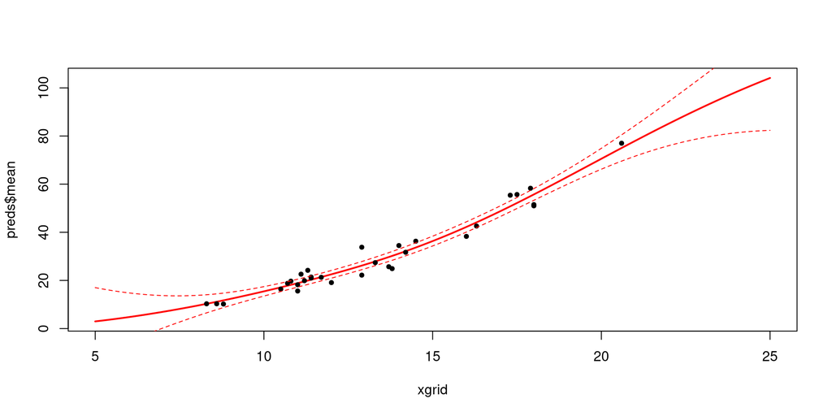

```r
plot(xgrid, preds$mean, type = "l",lwd = 2, col = "red")
points(trees$Girth, trees$Volume, pch = 20)
lines(xgrid, preds$lower95, col = "red", lty = 2)
lines(xgrid, preds$upper95, col = "red", lty = 2)
```

## Designing experiments for kriging?

Unlike the linear regression model, the variance can be zero at observations (no noise case).

Influence of the design locations on the predictive variance (same covariance)

```r
X1 <- seq(0, 1,, 5); y1 <- sin(X1 * 2 * pi)
X2 <- c(seq(0, 0.5,, 4), 0.8); y2 <- sin(X2 * 2 * pi)
km1 <- km(design = data.frame(x = X1), response = y1, coef.cov = 0.5, coef.var = 10)
km2 <- km(design = data.frame(x = X2), response = y2, coef.cov = 0.5, coef.var = 10)
```

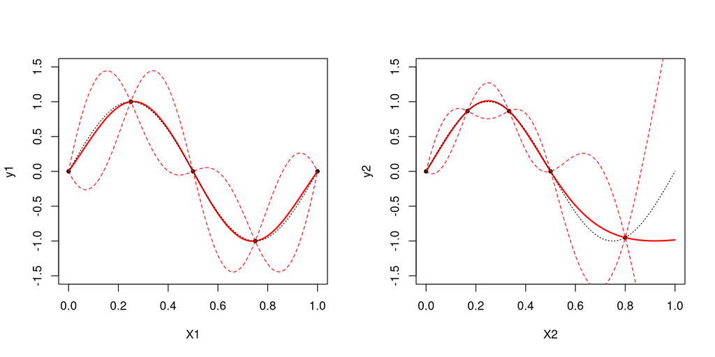

## Optimal designs for kriging

Unlike generalized linear regression, optimal designs related to learning the hyperparameters (covariance, trend) do not coincide with those optimal for the variance of the prediction.

But the equivalent criteria can be defined:

**D-optimality**: considering the likelihood, this is equivalent to maximizing \(Det(\mathbf{K})\)

**G-optimality**: still minimizing the maximum of the predictive variance, i.e., \[\min \limits_{\mathbf{X}} \max \limits_{\mathbb{x} \in D} s_n^2(\mathbf{x})\] with \(s_n^2(\mathbf{x})\) the predictive variance from kriging

**I-optimality**: minimize the integral of the variance of the prediction on \(D\), i.e., \[\min \limits_{\mathbf{X}} \int \limits_{\mathbb{x} \in D} s_n^2(\mathbf{x}) d\mathbf{x}\]

## Practical considerations

Remarks:

- D-optimality seems to target the greatest variety of inter-distances (in \(\mathbf{X})\)
- G-optimality adds points on the boundary of the domain
- The sequential version of D and G optimality are equivalent, see determinant update equation (e.g., Eq. 6.10 in Gramacy 2020.)
- I-optimality can be computed in closed-form for some classical kernels, alleviating the need for integration. Otherwise, the integral is replaced by a discrete sum over well-placed points (e.g., from a maximin LHS).

Brute force optimization of those criteria for the entire \(\mathbf{X}\) is often too expensive:

- high-dimensional multi-modal optimization problems
- require inner optimization (G-optimality) or, in some cases, integration (I-optimality)
- in addition, it is risky as it relies on unknown hyperparameters
- if hyperparameters are fixed, the result can be not so different from space-filling, just at a much higher computational cost

## Adaptive design

**Idea**: replace the initial optimization on \(\mathbf{X}\) by smaller optimization problems

In general, \(n_0\) designs are fixed with an initial space-filling design (e.g., maximin LHS). Then, for \(n_0 + 1 \leq i \leq n\), add designs corresponding to:

- (maxVar or [ALM](https://web.archive.org/web/20170829145418/https://pdfs.semanticscholar.org/9687/e167e4175c9cdd4fce236fa2d049fb0f93ed.pdf)) \(\arg\max \limits_{\mathbf{x} \in D} s_{i}^2(\mathbf{x})\)
- or, (IMSE, \(\approx\) [ALC](https://web.archive.org/web/20170829145418/https://pdfs.semanticscholar.org/9687/e167e4175c9cdd4fce236fa2d049fb0f93ed.pdf)) \(\arg \min \int \limits_{\mathbf{x} \in D} s_{i}^2(\mathbf{x})\)

Bonus:

- [kriging update formulas](https://hal.archives-ouvertes.fr/hal-00683362/document) can reduce the computational cost of those criteria from \(O(n^3)\) to \(O(n^2)\)
- monitoring the value of the criteria is possible

## Summary

- Being sequential allows to adapt as new data comes
- how to allocate **replicates**? Given a set of unique designs, optimal \(a_i^* \propto v(\bar{x}_i) K_i = (K_n^{-1} W K_n^{-1})_{i,i}\) comes from a criteria in the [stochastic kriging literature](http://users.iems.northwestern.edu/~bea/articles/stochastic%20kriging%20for%20simulation%20metamodeling.pdf).
- being Bayesian on GPs hyperparameters may attenuate problems

Limitations:

- with stationary kernels, the result may end up being similar to a space filling design
- poor estimation of the hyperparameters may never be recovered from

## Wrapup

## Conclusion

**Good practice**: normalizing designs to \([0, 1]^d\)

Many results for generalized linear regression, less for GPs but they are more flexible and particularly suited for sequential design.

Perspectives:

- arbitrary domain \(D\)?
- design of experiments (*active learning* in ML) is still an area for research, especially for complex noise/outputs
- articulation with optimization (what should be the size \(n_0\)?)

## References

- [R.B. Gramacy](https://bobby.gramacy.com/), [B. Iooss](http://www.gdr-mascotnum.fr/iooss1.html) and [V. Picheny](https://sites.google.com/site/victorpicheny/) lectures on Design of experiments
- Ghosh, S., & Rao, C. R. (Eds.). (1996). Design and analysis of experiments. Amsterdam: Elsevier.
- Dean, A., Morris, M., Stufken, J., & Bingham, D. (Eds.). (2015). Handbook of design and analysis of experiments (Vol. 7). CRC Press.
- Myers R.H., Montgomery D.C. (1995). Response Surface Methodology, Wiley New-York.
- `R` packages: [DiceDesign](https://cran.r-project.org/web/packages/DiceDesign/index.html), [randtoolbox](https://cran.r-project.org/web/packages/randtoolbox/index.html), [lhs](https://cran.r-project.org/web/packages/lhs/index.html), [MaxPro](https://cran.r-project.org/web/packages/MaxPro/index.html), and [many others](https://cran.r-project.org/web/views/ExperimentalDesign.html)
- (few) historical references: Fedorov, Taguchi, McKay, Sacks, …
- websites: www.spacefillingdesigns.nl , www.packomania.com